# Analysis of weather events on human health and economy

haoeric

11 July, 2014

## Synopsis

Storms and other severe weather events can cause both public health and economic problems for communitiesand municipalities. Many severe events can result in fatalities, injuries, and property damage, and preventing such outcomes to the extent possible is a key concern.

## 1.Data Processing

1.1 get the data Download the file from NOAA Storm Database

```r
#File_Url <- "https://d396qusza40orc.cloudfront.net/repdata%2Fdata%2FStormData.csv.bz2"
#download.file(file_Url, destfile = "/Users/chenhao/Ranalysis/StormData.csv.bz2", method = "curl")
```

1.2 Reading the data Decompress the file and read it

```r
#sd <- bzfile("/Users/chenhao/Ranalysis/StormData.csv.bz2", "StormData.csv")
storm_data <- read.csv("/Users/chenhao/Ranalysis/StormData.csv", stringsAsFactors = F)
#unlink(sd)
```

1.3 Take a first look at the data Let’s see what’s in the dataset

```r
head(storm_data)
```

```
##   STATE__           BGN_DATE BGN_TIME TIME_ZONE COUNTY COUNTYNAME STATE
## 1       1  4/18/1950 0:00:00     0130       CST     97     MOBILE    AL
## 2       1  4/18/1950 0:00:00     0145       CST      3    BALDWIN    AL
## 3       1  2/20/1951 0:00:00     1600       CST     57    FAYETTE    AL
## 4       1   6/8/1951 0:00:00     0900       CST     89    MADISON    AL
## 5       1 11/15/1951 0:00:00     1500       CST     43    CULLMAN    AL
## 6       1 11/15/1951 0:00:00     2000       CST     77 LAUDERDALE    AL
##    EVTYPE BGN_RANGE BGN_AZI BGN_LOCATI END_DATE END_TIME COUNTY_END
## 1 TORNADO         0                                               0
## 2 TORNADO         0                                               0
## 3 TORNADO         0                                               0
## 4 TORNADO         0                                               0
## 5 TORNADO         0                                               0
## 6 TORNADO         0                                               0
##   COUNTYENDN END_RANGE END_AZI END_LOCATI LENGTH WIDTH F MAG FATALITIES
```

[output cut: 20 more lines]

```r
str(storm_data)
```

```
## 'data.frame':    902297 obs. of  37 variables:
##  $ STATE__   : num  1 1 1 1 1 1 1 1 1 1 ...
##  $ BGN_DATE  : chr  "4/18/1950 0:00:00" "4/18/1950 0:00:00" "2/20/1951 0:00:00" "6/8/1951 0:00:00" ...
##  $ BGN_TIME  : chr  "0130" "0145" "1600" "0900" ...
##  $ TIME_ZONE : chr  "CST" "CST" "CST" "CST" ...
##  $ COUNTY    : num  97 3 57 89 43 77 9 123 125 57 ...
##  $ COUNTYNAME: chr  "MOBILE" "BALDWIN" "FAYETTE" "MADISON" ...
##  $ STATE     : chr  "AL" "AL" "AL" "AL" ...
##  $ EVTYPE    : chr  "TORNADO" "TORNADO" "TORNADO" "TORNADO" ...
##  $ BGN_RANGE : num  0 0 0 0 0 0 0 0 0 0 ...
##  $ BGN_AZI   : chr  "" "" "" "" ...
##  $ BGN_LOCATI: chr  "" "" "" "" ...
##  $ END_DATE  : chr  "" "" "" "" ...
##  $ END_TIME  : chr  "" "" "" "" ...
##  $ COUNTY_END: num  0 0 0 0 0 0 0 0 0 0 ...
```

[output cut: 23 more lines]

## 2.Results

2.1 Check all types of weather events:

```r
eventype <- sort(unique(storm_data$EVTYPE))
storm_data$EVTYPE <- as.factor(toupper(storm_data$EVTYPE))
```

2.2 Plot the top 10 events that cause maximun fatalities and injuries:

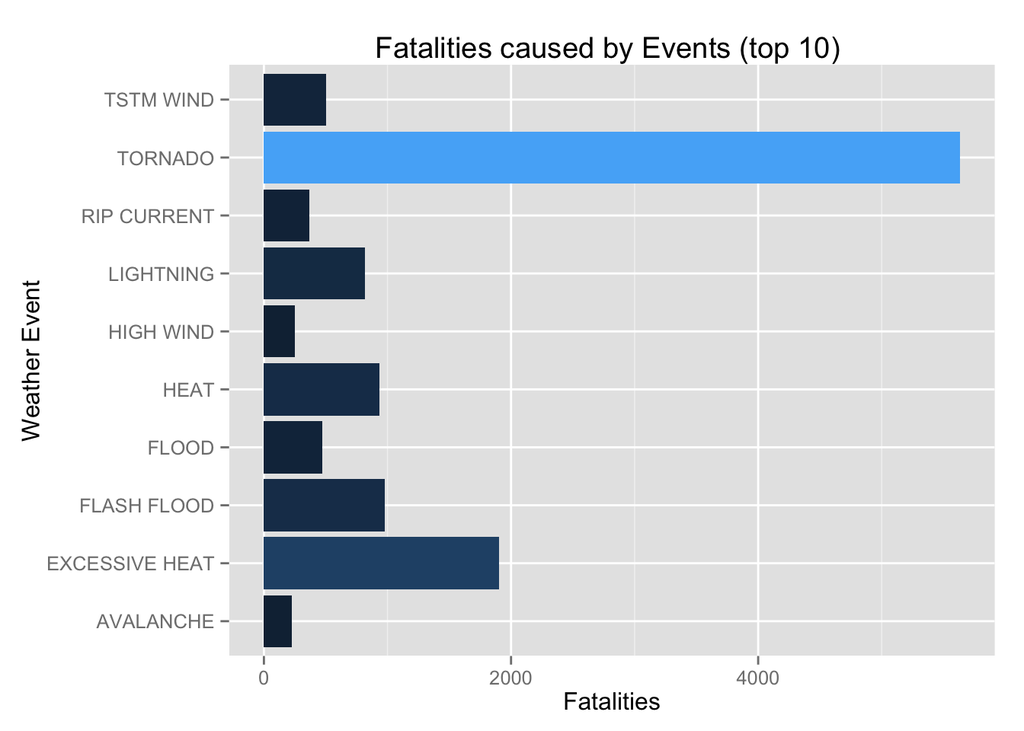

```r
harm <- aggregate(cbind(FATALITIES,INJURIES) ~ EVTYPE, data = storm_data, sum)
harm <- subset(harm, FATALITIES > 0 | INJURIES > 0)
top_fatalities <- harm[order(-harm$FATALITIES),][1:10,]
top_injuries <- harm[order(-harm$INJURIES),][1:10,]

library(ggplot2)
par(mfrow=c(1,2))
ggplot(data = top_fatalities, aes(EVTYPE, FATALITIES, fill = FATALITIES)) +
        geom_bar(stat = "identity") + xlab("Weather Event") + ylab("Fatalities") +
        ggtitle("Fatalities caused by Events (top 10) ") +
        coord_flip() + theme(legend.position = "none")
```

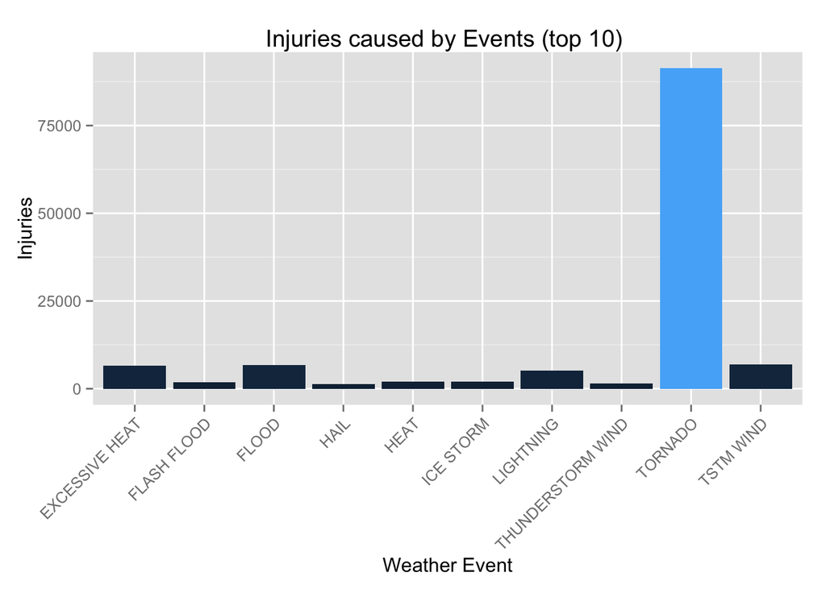

```r
ggplot(data = top_injuries, aes(EVTYPE, INJURIES, fill = INJURIES)) +
        geom_bar(stat = "identity") + xlab("Weather Event") + ylab("Injuries") +
        ggtitle("Injuries caused by Events (top 10) ") +
        theme(axis.text.x=element_text(angle = 45, hjust = 1)) +
        theme(legend.position = "none")
```

We can clearly see from the plot that **tornado** are most harmful with respect to population health.

2.3 Economic Impact of Weather Events Take a glance of economic cost related items first

```r
table(storm_data$PROPDMGEXP)
```

```
##
##             +      -      0      1      2      3      4      5      6
## 465934      5      1    216     25     13      4      4     28      4
##      7      8      ?      B      H      K      M      h      m
##      5      1      8     40      6 424665  11330      1      7
```

```r
summary(storm_data$PROPDMG)
```

```
##    Min. 1st Qu.  Median    Mean 3rd Qu.    Max.
##       0       0       0      12       0    5000
```

2.4 Combine the PROPDMGEX and PROPDMG to get the economic cost caused by different weather events, and see the summary

```r
# combine the PROPDMGEX and PROPDMG to get the economic cost
econo_costs <- rep(0, length(storm_data$PROPDMGEX))

for (i in 1:length(storm_data$PROPDMGEX)){
        if (storm_data$PROPDMGEX[i] == ""){
                econo_costs[i] <- storm_data$PROPDMG[i]
        }
        else{
                unit <- switch(EXPR = storm_data$PROPDMGEX[i],
                               '-' = -1, '?' = 1, '+' = 1, '1' = 1, '2' = 10^2, '3' = 10^3,
                               '4' = 10^4, '5' = 10^5, '6' = 10^6, '7' = 10^7, '8' = 10^8,
                               'h' = 100, 'K' = 1000, 'm' = 10^6, 'B' = 10^9,'0'=1,
                               'H' = 100, 'M' = 10^6
                )
                econo_costs[i] <- storm_data$PROPDMG[i] * unit
        }
}

storm_data$ECONOMIC_COST <- econo_costs
summary(storm_data$ECONOMIC_COST)
```

```
##      Min.   1st Qu.    Median      Mean   3rd Qu.      Max.
## -1.50e+01  0.00e+00  0.00e+00  4.75e+05  5.00e+02  1.15e+11
```

2.5 Plot the top 10 events that caused the maximum economic cost

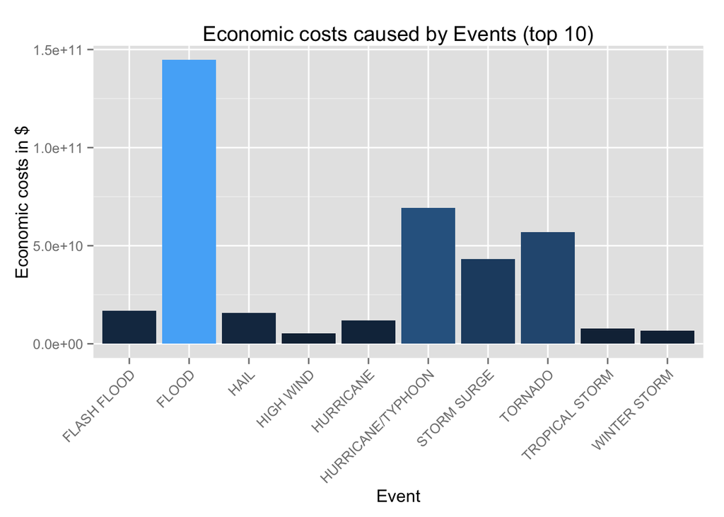

```r
cost <- aggregate(ECONOMIC_COST ~ EVTYPE, data = storm_data, sum)
# get the top 10 items
top_cost <- cost[order(-cost$ECONOMIC_COST),][1:10,]

ggplot(data = top_cost, aes(EVTYPE, ECONOMIC_COST, fill = ECONOMIC_COST)) +
        geom_bar(stat = "identity") + xlab("Event") +
        theme(axis.text.x=element_text(angle = 45, hjust = 1)) +
        ylab("Economic costs in $") + ggtitle("Economic costs caused by Events (top 10)") +
        theme(legend.position = "none")
```

It’s clear that Flood caused the maximum economic cost.